# CNN

## Convolutional Neural Network (CNN)

##### Convolutional neural networks: definition and elements.

Convolutional neural networks (CNNs) are a class of Deep Artificial Neural Networks that are commonly applied to image processing tasks, such as object detection and identification.

CNNs share the underlying structure with the MLPs seen previously, in fact:

1. Feed Forward Structure: they generally organize their nodes (or neurons) into layers, with the output of each layer fed forward to the next layer for further processing.
2. Learning through backpropagation: during training, a loss function is used to calculate the error margin between the actual output and the desired output. This error margin is then used to update the weights through a process known as backpropagation, with the goal of reducing the loss function and thus the error margin.

MLPs can only work with images if they are first converted into a vector of pixel values. The problem with this transformation is the potential loss of spatial integrity, as information about how pixels combine with each other could be lost.

Convolutional neural networks maintain the spatial integrity of input images because they can extract information from a data matrix through convolutional filters; moreover, they can analyze color images (thus in three dimensions) by processing each channel individually, but keeping them grouped as the same input. In practice, convolutional filters are a set of weights that are applied to the pixel values in our input image. These weights are learned and refined through backpropagation during the training phase.

The use of convolutional filters in CNNs is inspired by the work of Hubel and Wiesel, two neuroscientists who studied how images trigger neuronal activation in the visual cortex. In their study, they suggested that visual processing is a hierarchical process that begins with the identification of basic features that are then combined into more complex constructs. Similarly, filters in CNNs allow the neural network to identify basic features and highlight them; these can then be forwarded for further processing, but must first be corrected by an activation function.

The filtering process, as can be seen in the example in Figure 2.16, consists of sliding a convolutional filter over an image and generating a filtered version of the image.

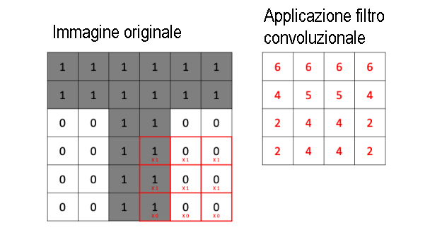

Esempio applicazione filtro convoluzionale

Convolutional filters can enhance and suppress specific features present in input images (for example curves, edges, or colors). Filters within a CNN can mainly differ in 4 characteristics:

- The number of convolutional filters: CNNs can have dozens or even hundreds of filters. Each convolutional filter generates its own feature map that is forwarded for further processing.
- Filter size: Convolutional filters must be large enough to account for features that span multiple pixels, but small enough to be reusable across an image.
- Stride: questo parametro indica il numero di pixel costituenti l’unità di spostamento per elaborazione. Passi più lunghi si tradurranno in una maggiore velocità computazionale ma in matrici più piccole con una potenziale perdita di caratteristiche importanti.
- Padding: allows, as exemplified in Figure 2.17, to modify the input image by filling it with empty pixels to ensure that the filtered image maintains the same dimensions as the original input image.

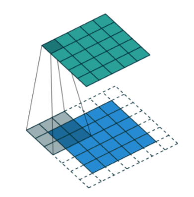

Applicazione di un filtro convoluzionale con imbottitura

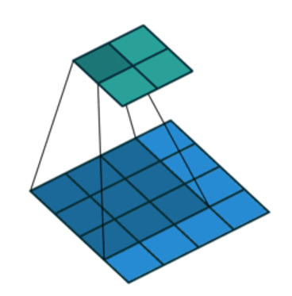

Applicazione di un filtro convoluzionale senza Padding

In a convolutional neural network, the inputs $I$ are images, thus matrices in three dimensions. Formally $I$ has dimension $H \times W \times C$ where $H W $ are the pixels while $C$ are the channels, therefore:

$$I \in \mathbb{R}^{H \times W \times C}$$

Assuming a filter $K \in \mathbb{R}^{k_1 \times k_2 \times C \times D}$ and a bias $b \in \mathbb{R}^{D}$ the output of the convolutional procedure is:

$$(I \ast K)_{ij} = \sum_{m = 0}^{k_1 - 1} \sum_{n = 0}^{k_2 - 1} \sum_{c = 1}^{C} K_{m,n,c} \cdot I_{i+m, j+n, c} + b$$

The weights and bias are updated through a forward-propagation and back-propagation procedure, generally inserting a fully connected MLP at the end of the filters.

In CNNs, the most common activation function is ReLU, because it ensures that only nodes with a positive activation send their values forward, which guarantees that:

- Con meno nodi attivati le elaborazioni da fare sono minori.
- I nodi che vengono attivati positivamente indicano aspetti significativi. Concentrarsi su questi può portare a modelli migliori con punteggi di precisione più elevati.
- C’è meno rumore all’interno della rete, riducendo i pericoli di overfitting o errori di correlazione tra input e uscita desiderata.

Un attributo comune nelle reti neurali convoluzionali è quello del Pooling, esemplificato in Figura 2.18. Il pooling avviene normalmente dopo che le mappe delle funzionalità sono state passate tramite la funzione di attivazione ReLU. L’obiettivo del pooling è ridurre le dimensioni della matrice dell’immagine senza perdita di informazioni. A sua volta, questa operazione, riduce la quantità di elaborazione richiesta, risparmiando tempo e risorse nella fase di formazione. Le varietà di pooling più comuni sono:

1. Max Pooling: Accetta il valore massimo in pixel all’interno del filtro.
   $$y_{ijk} = \max \{ y_{i'j'k} : i \leq i' < i+p, \space \space j \leq j' < j + p \}$$
2. Average pooling: Prende il valore medio dei pixel all’interno del filtro.
   $$y_{ijk} = mean \{ y_{i'j'k} : i \leq i' < i+p, \space \space j \leq j' < j + p \}$$
3. Sum Pooling: Somma i valori dei pixel all’interno del filtro.
   $$y_{ijk} = sum \{ y_{i'j'k} : i \leq i' < i+p, \space \space j \leq j' < j + p \}$$

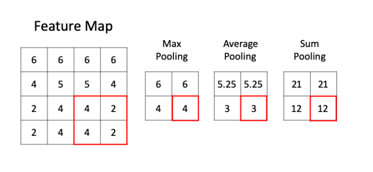

Esempio Pooling

Un altro importante elemento costitutivo della CNN è la normalizzazione (normalization batch). Per aumentare la stabilità di una rete neurale si sottrae dai valori in input la loro media batch e successivamente si dividono per la deviazione standard. La normalizzazione viene, di norma, attuata prima di un livello di attivazione ed è utilizzata per velocizzare il processo di riduzione al minimo la funzione di perdita.

$$\mu_B = \frac{1}{m} \sum_{i=1}^m x_i$$

$$\sigma_B^2 = \frac{1}{m} \sum_{i=1}^m (x_i-\mu_B)^2$$

$$\hat{x_i} = \frac{x_i - \mu_B}{\sqrt{\sigma^2_B + \epsilon}}$$

$$y_i = \gamma \hat x_i + \beta == BN_{\gamma,\beta}(x_i)$$

L’offset $\beta$ e lo scale factor $\gamma$ sono parametri apprendibili che vengono aggiornati nella back-propagation come fossero normali pesi. Se si imposta la $\gamma$ come 1 e $\beta$ come 0 l’intero processo è solo standardizzazione.